# “Text Mining Week 2 report”

“Justin G.”

“October 16, 2017”

## Introduction and Methodology

This writeup provides an update with regard to the text mining exercise used in the Capstone course of the Data Science Specialization. Using the Swiftkey dataset, this project is a step towards performing natural language processing, defined at http://searchbusinessanalytics.techtarget.com/definition/natural-language-processing-NLP as the ability of a computer program to understand human spoken languages, of three large data collections: one of news headlines (*usnews*), one of blog content (*usblogs*), and one of Twitter content (*ustweets*). All files come from material collected in English from the United States. The methodology behind creation of these three files can be found at: https://www.coursera.org/learn/data-science-project/supplement/4phKX/about-the-copora (page last accessed October 17, 2017).

Owing to the very, very sizeable nature of these datasets–processed ones are on the order of gigabytes–current and future processing will continue to involve the taking only a subset of the data available. Future assignments will also incorporate the ability to predict words using existing sequences. We nonetheless use R’s parallel package and employ constant use of the garbage cleanup function in order to perform perliminary analysis in a memory-efficient manner.

```r
library(knitr); library(tm); library(dplyr); library(stringr); library(parallel); library(doParallel); library(wordcloud); library(markdown); library(rmarkdown); library(tau)
```

After loading the aforementioned libraries, we set up a so-called parallel cluster in order to mitigate the time and computer resources needed to process the three files mentioned above. A parallel cluster basically means that we simulated the impacts of running multiple computers using just one, in order to speed up processing time. To pursue parallel clustering, we follow the instructions provided by course mentor Len Greski, available at: https://github.com/lgreski/datasciencectacontent/blob/master/markdown/pml-randomForestPerformance.md (last accessed October 15, 2017):

```r
cluster <- makeCluster(detectCores() - 1); registerDoParallel(cluster)
```

## Analysis

We now perform preliminary analyses on the three files mentioned above. Namely, we perform a (1) line count, (2) word count, and (3) data analysis on subsets of the three files mentioned earlier. We use *subsets* due to memory constraints, namely those of the computer on which this document was produced but also considering the much more substantive ones sure to occur with cell-phones. For instance, we only read in 12500 lines for each of the three files mentioned earlier, but if we read in the entire files, *usnews* would have 75000+ lines with greater than 80000 words, with *usblogs* coming in just short of 900,000 lines and with an indeterminate amount of words (because our system would freeze).

Our coding approach was adopted by that suggested at the page accessible at: https://stackoverflow.com/questions/26510298/rs-tm-package-for-word-count (last accessed October 17, 2017).

In order to clean up various aspects of the documents, including the removal of common words and excess whitespaces in order to ensure accurate character counts, we declare a function with that capability. This function is called during the analysis of each of the three documents.

```r
createCorpus<-function(Corpus) {
    Corpus<-tm_map(Corpus,PlainTextDocument)
    Corpus<-tm_map(Corpus, removePunctuation)
    Corpus<-tm_map(Corpus, stripWhitespace)
    Corpus<-tm_map(Corpus, removeWords, c(stopwords("english"), "[Tt]he"))
    Corpus<-tm_map(Corpus, stemDocument)
}
```

### Analysis: news stories

```r
#Set working directory
setwd("C:\\Users\\gold9629\\Documents\\Coursera_Capstone\\final\\en_US\\")

#Read in files, create corpora, and compute line counts, word counts, and data analysis
usnews <-file("en_US.news.txt", "r")
usnewsrl<-readLines(usnews, 12500, encoding="UTF-8")
usnewsrlcorpus<-VCorpus(VectorSource(usnewsrl)) %>%
  createCorpus()
close(usnews)

# Close cluster
stopCluster(cluster); registerDoSEQ()
```

We now calculate the total amount of words in our dataset, identify the most popular words, and generate a wordcloud of the most popular words. The following code was adapted from that at: https://datascienceplus.com/building-wordclouds-in-r/ (last accessed 2017-10-16).

```r
usnewsrldtm<-DocumentTermMatrix(usnewsrlcorpus)
dim(usnewsrldtm)[2] #  word count
```

```
## [1] 28195
```

```r
mostcommonWords<-findFreqTerms(usnewsrldtm, lowfreq=250)
mostcommonWords
```

```
##   [1] "also"    "and"     "ask"     "back"    "best"    "busi"    "but"
##   [8] "call"    "can"     "center"  "chang"   "citi"    "come"    "compani"
##  [15] "counti"  "day"     "dont"    "end"     "even"    "famili"  "first"
##  [22] "four"    "game"    "get"     "give"    "good"    "got"     "help"
##  [29] "high"    "home"    "hous"    "includ"  "its"     "job"     "just"
##  [36] "know"    "last"    "like"    "live"    "look"    "lot"     "made"
##  [43] "make"    "mani"    "may"     "million" "month"   "much"    "nation"
##  [50] "need"    "new"     "next"    "now"     "offic"   "offici"  "one"
##  [57] "open"    "park"    "part"    "peopl"   "percent" "place"   "plan"
##  [64] "play"    "point"   "polic"   "presid"  "public"  "report"  "right"
##  [71] "run"     "said"    "say"     "school"  "season"  "second"  "see"
##  [78] "servic"  "show"    "sinc"    "start"   "state"   "still"   "support"
##  [85] "take"    "team"    "that"    "there"   "they"    "thing"   "think"
##  [92] "this"    "three"   "time"    "tri"     "two"     "use"     "want"
##  [99] "way"     "week"    "well"    "will"    "work"    "year"
```

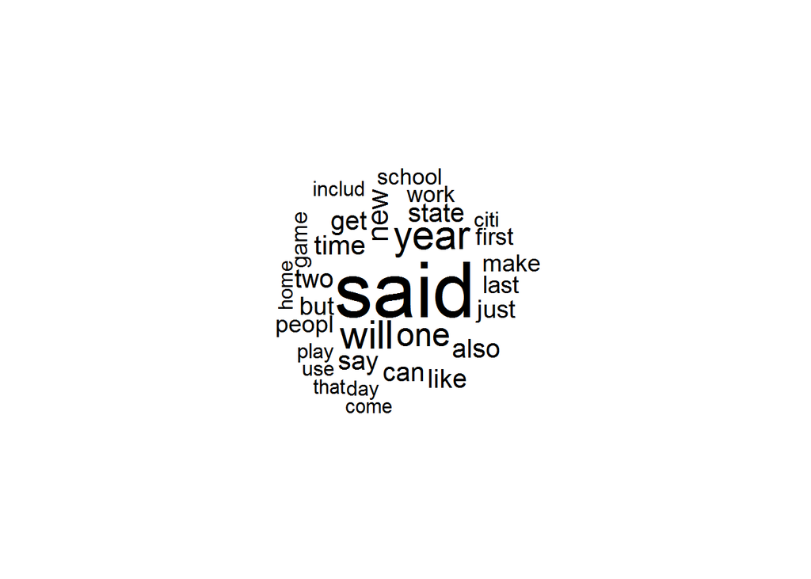

```r
wordcloud(usnewsrlcorpus, max.words=30, random.order=FALSE)
```

```r
invisible(gc(verbose = getOption("verbose"), reset = TRUE))
```

The word cloud illustrates that the word “said” is by far and away the most frequently used word in the document.

### Analysis: blogs

```r
#Recreate cluster.
cluster <- makeCluster(detectCores() - 1); registerDoParallel(cluster)

#Set working directory
setwd("C:\\Users\\gold9629\\Documents\\Coursera_Capstone\\final\\en_US\\")

# Read in files, create corpora, and compute line counts, word counts, and data analysis
usblogs <-file("en_US.blogs.txt", "r")
usblogsrl<-readLines(usblogs, 12500, encoding="UTF-8")
usblogsrlcorpus<-VCorpus(VectorSource(usblogsrl) ) %>%
  createCorpus()
close(usblogs)
invisible(gc(verbose = getOption("verbose"), reset = TRUE)) # Run garbage cleanup for memory

# Close cluster
stopCluster(cluster); registerDoSEQ()
```

```r
usblogsrldtm<-DocumentTermMatrix(usblogsrlcorpus) #Each element in the matrix is one word.
dim(usblogsrldtm)[2] # word count
```

```
## [1] 28804
```

```r
mostcommonWords<-findFreqTerms(usnewsrldtm, lowfreq=250)
mostcommonWords
```

[output not shown]

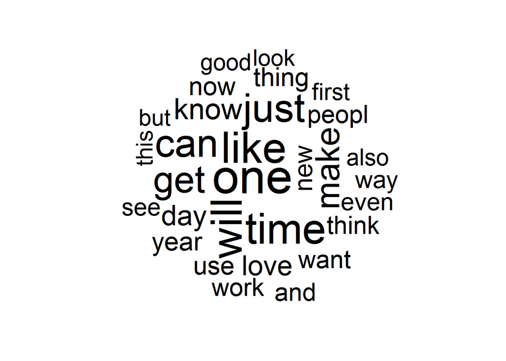

```r
wordcloud(usblogsrlcorpus, max.words=30, random.order=FALSE)
```

```r
invisible(gc(verbose = getOption("verbose"), reset = TRUE)) #cleanup
```

As shown in the above word cloud, the word “one” appears most frequently, with “will,” “get,” “like,” and “time” also appearing frequently.

```r
#Recreate cluster.
cluster <- makeCluster(detectCores() - 1); registerDoParallel(cluster)

#Set working directory
setwd("C:\\Users\\gold9629\\Documents\\Coursera_Capstone\\final\\en_US\\")

# Read in files, create corpora, and compute line counts, word counts, and data analysis
ustweets <-file("en_US.blogs.txt", "r")
ustweetsrl<-readLines(ustweets, 12500)
ustweetsrlcorpus<-VCorpus(VectorSource(ustweetsrl)) %>%
  createCorpus()
close(ustweets)
invisible(gc(verbose = getOption("verbose"), reset = TRUE)) # Run garbage cleanup for memory

# Close cluster
stopCluster(cluster); registerDoSEQ()
```

```r
ustweetsrldtm<-DocumentTermMatrix(ustweetsrlcorpus) #Each element in the matrix is one word.
dim(ustweetsrldtm)[2] # word count
```

```
## [1] 29014
```

```r
mostcommonWords<-findFreqTerms(usnewsrldtm, lowfreq=250)
mostcommonWords
```

[output not shown]

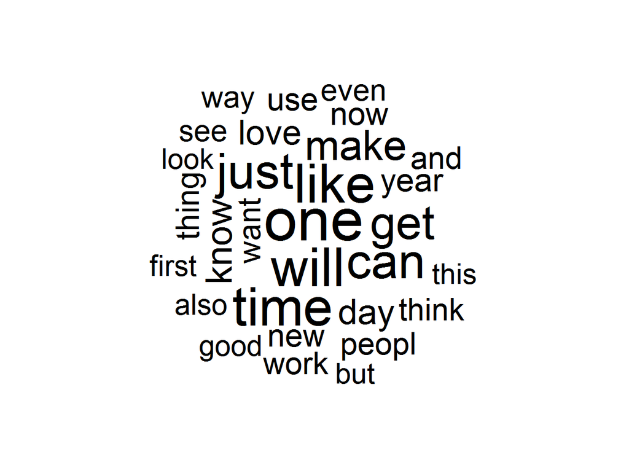

```r
wordcloud(ustweetsrlcorpus, max.words=30, random.order=FALSE)
```

```r
invisible(gc(verbose = getOption("verbose"), reset = TRUE)) #cleanup
```

## Analysis and Conclusions

Below, we present a table illustrating the word count for each of our 12500 line samples:

```r
setwd("C:\\Users\\gold9629\\Documents\\Coursera_Capstone\\final\\en_US\\")
results=matrix(c("usnews", "usblogs", "ustweets", dim(usnewsrldtm)[2],  dim(usblogsrldtm)[2], dim(ustweetsrldtm)[2]), nrow=3)
colnames(results) <- c("Files", "WordCounts")
kable(results, caption = "Word count for each 12500 line file")
```

Word count for each 12500 line file

| Files | WordCounts |
| --- | --- |
| usnews | 28195 |
| usblogs | 28804 |
| ustweets | 29014 |

We also refer the reader to the word clouds and word summaries above.

Future plans include: * Invoking filters to remove profanity, particularly from the *ustweets* dataset since we don’t want to be predicting on such terms (see instructions) * Deployment of continuous “garbage cleanup” and the RProfiler, tools both used to free-up memory. The use of parallel computing will continue. * Deployment of algorithms to predict words based on previous words in a phrase (see above) * Continued prototyping of the shiny app, which will hopefully allow a user to enter phrases and allow the app to predict words, and vice-versa. * Refinement of the prediction algorithm to encompass more than 12500 lines without sacrificing memory. Additionally, the prediction algorithm needs to select lines at random, not just the first 12500 lines. Exploration of using the binomial function to accomplish this task, per the suggestion in the instructions, may help.